# Statistics in Python: Euser Analysis

⇦ Back

This page is a follow-on of this one on Bland-Altman analysis and this one on Giavarina analysis:

**Bland-Altman analysis** is used to assess the agreement between two methods of measuring something, usually clinical information. It was discussed in Bland & Altman’s 1986 paper<sup>[1]</sup> and see also the [Wikipedia page](https://en.wikipedia.org/wiki/Bland%E2%80%93Altman_plot).

**Giavarina analysis** is identical to Bland-Altman analysis except that it accounts for [heteroscedasticity](https://en.wikipedia.org/wiki/Heteroscedasticity). It does this by using percentage differences (relative to the means) on the y-axis instead of raw differences. It was published in Giavarina’s 2015 paper<sup>[2]</sup>.

**Euser analysis** also accounts for heteroscedasticity except that it does so via a logarithmic transformation. While this approach was mentioned in Bland & Altman (1986) it was Euser, Dekker & Le Cessie who published a method to transform the data back into the native space and calculate a meaningful coefficient of variation<sup>[3]</sup>.

Calculating agreement is useful when discussing:

- Test-retest experiments
- Repeatability and reproducibility
- Reliability
- Intra- and inter-operator agreement
- Intra- and inter-test agreement

> [1] Bland JM, Altman DG. Statistical methods for assessing agreement between two methods of clinical measurement. Lancet. 1986 Feb;327(8476):307–10. DOI: [10.1016/S0140-6736(86)90837-8](https://linkinghub.elsevier.com/retrieve/pii/S0140673686908378). PMID: [2868172](https://pubmed.ncbi.nlm.nih.gov/2868172/).

> [2] Giavarina D. Understanding Bland Altman analysis. Biochemia Medica. 2015;25(2):141-151. DOI: [10.11613/BM.2015.015](https://www.ncbi.nlm.nih.gov/pmc/articles/PMC4470095/pdf/bm-25-141.pdf).

> [3] Euser AM, Dekker FW, Le Cessie S. A practical approach to Bland-Altman plots and variation coefficients for log transformed variables. J Clin Epidemiol. 2008;61(10):978–82. DOI: [10.1016/j.jclinepi.2007.11.003](http://citeseerx.ist.psu.edu/viewdoc/download?doi=10.1.1.564.9186&rep=rep1&type=pdf)

# 1 Raw Data

The Euser, Dekker & Le Cessie (2008) paper use data from an investigation into the reproducibility of measurements of the thickness of skinfolds around participants’ biceps. In the investigation, 13 observers took measurements from 4 subjects (yielding 13 × 4 = 52 measurements) on two occasions, resulting in the following data:

```python
import pandas as pd

# Create raw data
raw_data = {
    'Measurement 1': [
        7.5, 8.6, 8.6, 8.6, 8.3, 9.2, 9.2, 9.9, 9.8, 9.4, 9.3, 9.6, 10.6, 10.2,
        11.7, 11.4, 11.8, 11.4, 12.0, 12.4, 12.2, 12.0, 11.6, 11.8, 13.6, 15.3,
        15.0, 15.4, 15.5, 17.0, 16.8, 16.5, 17.0, 18.2, 18.3, 20.1, 21.5, 21.0,
        22.6, 23.0, 25.0, 24.0, 27.0, 21.0, 15.5, 17.0, 17.0, 24.5, 14.0, 11.0,
        17.8, 9.2
    ],
    'Measurement 2': [
        7.3, 7.8, 8.0, 8.4, 8.5, 9.0, 9.0, 9.3, 9.7, 9.8, 10.0, 10.0, 10.0,
        10.2, 11.2, 11.3, 11.6, 11.8, 12.2, 12.5, 12.7, 12.9, 12.7, 13.0, 14.8,
        13.8, 15.0, 15.5, 15.2, 15.0, 15.6, 16.2, 16.0, 18.0, 18.1, 20.1, 19.0,
        21.2, 22.2, 21.8, 23.0, 17.8, 19.0, 23.0, 17.9, 20.0, 22.6, 29.0, 16.0,
        13.0, 14.2, 9.0
    ],
}
df = pd.DataFrame(raw_data)
```

Summary statistics about this data are as follows (this replicates the first part of Table 1 of Euser (2008)):

```python
print(f'Sample size, n = {df.shape[0]}')
print(f'Minimum = {df.min().min()}')
print(f'Maximum = {df.max().max()}')
print(f'Mean = {df.stack().mean()}')
```

```
## Sample size, n = 52
## Minimum = 7.3
## Maximum = 29.0
## Mean = 14.498076923076924
```

# 2 Bland-Altman Analysis

‘Traditional’ Bland-Altman analysis can be performed in the usual way:

```python
import numpy as np
from scipy.stats import norm

# Bland-Altman analysis
means = df.mean(axis=1)
diffs = df.diff(axis=1, periods=-1).iloc[:, 0]
# Average difference (aka the bias)
bias = np.mean(diffs)
# Sample standard deviation
s = np.std(diffs, ddof=1)
# 95% limits of agreement
C = 0.95  # Confidence level = 95%
alpha = (1 - C) / 2  # Significance level
z_star = norm.ppf(alpha)  # Critical value
upper_loa = bias - z_star * s
lower_loa = bias + z_star * s
```

> Note that the critical value ($z^*$) used when calculating the limits of agreement is being generated ‘the long way’ in this example by looking up the alpha value in the normal distribution’s percent-point function (PPF). Using `z_star = 1.96` (which is what is done in the Euser paper) or even `z_star = 2` (which is done in some of Bland & Altman’s papers) is usually accurate enough.

We can now plot the results, starting with some code to set the format of the graphs:

```python
import matplotlib.pyplot as plt

# Options
x = 5  # Want figures to be A5
plt.rc('figure', figsize=[46.82 * .5**(.5 * x), 33.11 * .5**(.5 * x)])
plt.rc('text', usetex=True)
plt.rc('font', family='serif')
plt.rc('text.latex', preamble=r'\usepackage{textgreek}')
```

Plotting the results replicates Figure 1 from Euser (2008):

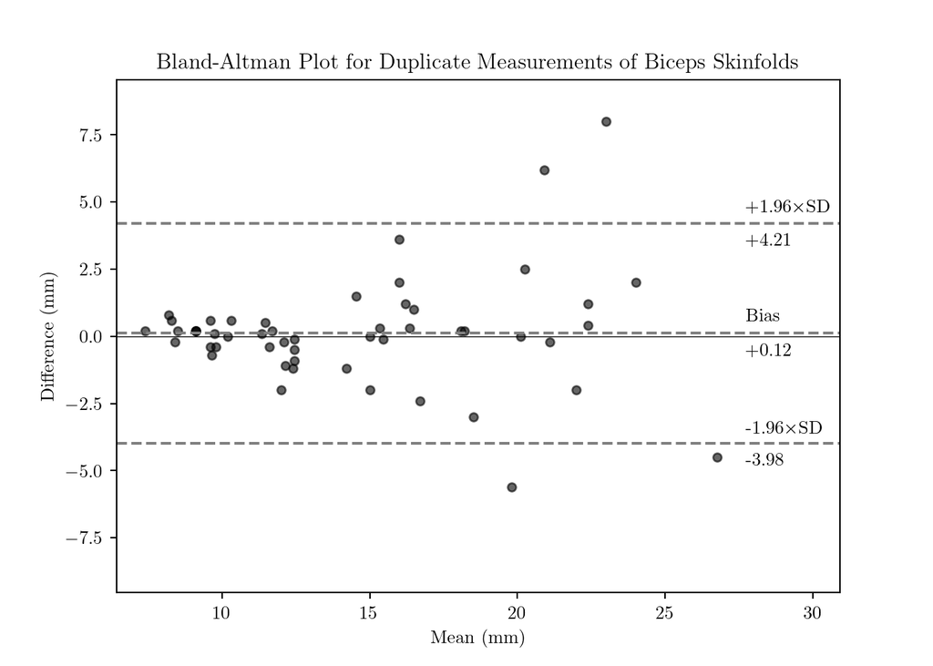

```python
#
# Plot
#
ax = plt.axes()
ax.set(
    title='Bland-Altman Plot for Duplicate Measurements of Biceps Skinfolds',
    xlabel='Mean (mm)', ylabel='Difference (mm)'
)
# Scatter plot
ax.scatter(means, diffs, c='k', s=20, alpha=0.6, marker='o')
# Plot the zero line
ax.axhline(y=0, c='k', lw=0.5)
# Plot the bias and the limits of agreement
ax.axhline(y=upper_loa, c='grey', ls='--')
ax.axhline(y=bias, c='grey', ls='--')
ax.axhline(y=lower_loa, c='grey', ls='--')
# Get axis limits
left, right = plt.xlim()
bottom, top = plt.ylim()
# Set y-axis limits
max_y = max(abs(bottom), abs(top))
ax.set_ylim(-max_y * 1.1, max_y * 1.1)
# Set x-axis limits
domain = right - left
ax.set_xlim(left, left + domain * 1.15)
# Add the annotations
ax.annotate('+1.96×SD', (right, upper_loa), (0, 6), textcoords='offset points')
ax.annotate(f'{upper_loa:+4.2f}', (right, upper_loa), (0, -12), textcoords='offset points')
ax.annotate('Bias', (right, bias), (0, 6), textcoords='offset points')
ax.annotate(f'{bias:+4.2f}', (right, bias), (0, -12), textcoords='offset points')
ax.annotate('-1.96×SD', (right, lower_loa), (0, 6), textcoords='offset points')
ax.annotate(f'{lower_loa:+4.2f}', (right, lower_loa), (0, -12), textcoords='offset points')
# Show plot
plt.show()
```

Note that in Euser (2008) they have ±4.09 mm as their limits of agreement as opposed to 4.21 and -3.98 which are shown in the above. This is because they round off their bias from 0.12 to 0 which results in the critical difference (1.96 × s) being the same as the absolute value of both LOAs:

```python
# Print the critical difference
print(f'{z_star * s:4.2f}')
```

```
## -4.09
```

# 3 Euser Analysis

The basis of Euser analysis is the transformation of the data into the log 10 space:

```python
df_log10 = np.log10(df)
```

The summary statistics of the transformed data look as follows (this replicates the first part of Table 1 of Euser (2008)):

```python
print(f'Sample size, n = {df_log10.shape[0]}')
print(f'Minimum = {df_log10.min().min():4.2f}')
print(f'Maximum = {df_log10.max().max():4.2f}')
print(f'Mean = {df_log10.stack().mean():4.2f}')
```

```
## Sample size, n = 52
## Minimum = 0.86
## Maximum = 1.46
## Mean = 1.14
```

The residual-error variance (average within-subject sample variance) and intra-observer coefficient of variation can be calculated immediately (also from Table 1):

```python
# Residual-error variance (average within-subject sample variance)
s = np.std(df_log10, ddof=1, axis=1)
residual_error_variance = np.mean(s**2)
print(f'Residual-error variance = {residual_error_variance:5.3e}')
```

```
## Residual-error variance = 1.099e-03
```

```python
# Intra-observer CV (%)
cv = np.log(10) * np.sqrt(residual_error_variance) * 100
print(f'Intra-observer CV = {cv:3.1f}%')
```

```
## Intra-observer CV = 7.6%
```

After this point, the analysis is identical to Bland-Altman:

```python
means = df_log10.mean(axis=1)
diffs = df_log10.diff(axis=1, periods=-1).iloc[:, 0]
# Average difference (aka the bias)
bias = np.mean(diffs)
# Sample standard deviation
s = np.std(diffs, ddof=1)
# 95% limits of agreement
C = 0.95  # Confidence level = 95%
alpha = (1 - C) / 2  # Significance level
z_star = norm.ppf(alpha)  # Critical value
upper_loa = bias - z_star * s
lower_loa = bias + z_star * s
```

## 3.1 Plot in the Log Space

Plotting the results in the log space replicates Figure 2 of Euser (2008):

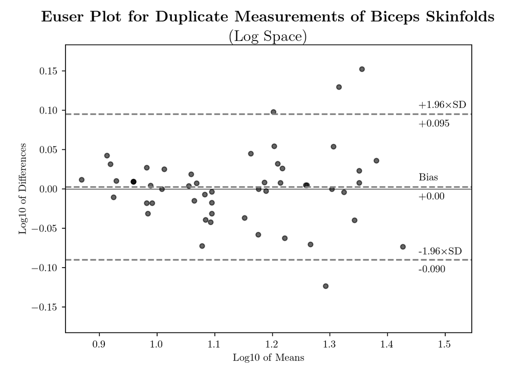

```python
#
# Plot
#
ax = plt.axes()
ax.set_title(
    r'\begin{center}{\bf Euser Plot for Duplicate Measurements of Biceps Skinfolds}\\(Log Space)\end{center}',
    fontsize = 15
)
ax.set_ylabel('Log10 of Differences')
ax.set_xlabel('Log10 of Means')
# Scatter plot
ax.scatter(means, diffs, c='k', s=20, alpha=0.6, marker='o')
# Plot the zero line
ax.axhline(y=0, c='k', lw=0.5)
# Plot the bias and the limits of agreement
ax.axhline(y=upper_loa, c='grey', ls='--')
ax.axhline(y=bias, c='grey', ls='--')
ax.axhline(y=lower_loa, c='grey', ls='--')
# Get axis limits
left, right = plt.xlim()
bottom, top = plt.ylim()
# Set y-axis limits
max_y = max(abs(bottom), abs(top))
ax.set_ylim(-max_y * 1.1, max_y * 1.1)
# Set x-axis limits
domain = right - left
ax.set_xlim(left, left + domain * 1.15)
# Add the annotations
ax.annotate('+1.96×SD', (right, upper_loa), (0, 6), textcoords='offset points')
ax.annotate(f'{upper_loa:+5.3f}', (right, upper_loa), (0, -12), textcoords='offset points')
ax.annotate('Bias', (right, bias), (0, 6), textcoords='offset points')
ax.annotate(f'{bias:+4.2f}', (right, bias), (0, -12), textcoords='offset points')
ax.annotate('-1.96×SD', (right, lower_loa), (0, 6), textcoords='offset points')
ax.annotate(f'{lower_loa:+5.3f}', (right, lower_loa), (0, -12), textcoords='offset points')
# Show plot
plt.show()
```

Again, their limits of agreement (±0.092) are equal to the critical difference (1.96 × s), give or take rounding errors:

```python
# Print the critical difference
print(f'{z_star * s:5.3f}')
```

```
## -0.093
```

## 3.2 Back-Transform the Limits of Agreement

In the log space the limits of agreement are horizontal lines, but they can be transformed back into the native space where they appear as diagonal lines on a Bland-Altman plot. The formula given in Euser (2008) is:

$\pm 2 \times \dfrac{10^a - 1}{10^a + 1} \times \bar{X}$

where the values of $a$ are the limits of agreement in the log space and $\bar{X}$ are the arithmetic means of the data (ie the x-axis of the Bland-Altman plot):

```python
# Convert the LOAs from horizontal lines in the log space to gradients of
# diagonal lines in the native space
upper_loa_m = 2 * (10**upper_loa - 1) / (10**upper_loa + 1)
lower_loa_m = 2 * (10**lower_loa - 1) / (10**lower_loa + 1)
```

The Bland-Altman plot can now be re-drawn (Figure 3 of Euser (2008)):

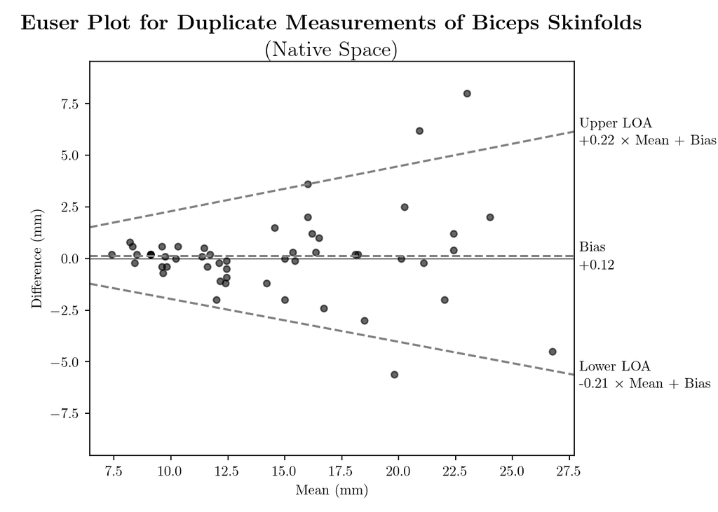

```python
# Bland-Altman analysis
means = df.mean(axis=1)
diffs = df.diff(axis=1, periods=-1).iloc[:, 0]
# Average difference (aka the bias)
bias = np.mean(diffs)

#
# Plot
#
ax = plt.axes()
ax.set_title(
    r'\begin{center}{\bf Euser Plot for Duplicate Measurements of Biceps Skinfolds}\\(Native Space)\end{center}',
    fontsize = 15
)
ax.set_ylabel('Difference (mm)')
ax.set_xlabel('Mean (mm)')
# Scatter plot
ax.scatter(means, diffs, c='k', s=20, alpha=0.6, marker='o')
# Plot the zero line
ax.axhline(y=0, c='k', lw=0.5)
# Get axis limits
left, right = plt.xlim()
bottom, top = plt.ylim()
# Set y-axis limits
max_y = max(abs(bottom), abs(top))
ax.set_ylim(-max_y * 1.1, max_y * 1.1)
# Set x-axis limits
domain = right - left
# right_edge = left + domain * 1.12
ax.set_xlim(left, right)
# Plot the bias
ax.axhline(y=bias, c='grey', ls='--')
# Plot the limits of agreement
x = np.array([left, right])
y = upper_loa_m * x + bias
ax.plot(x, y, c='grey', ls='--')
y = lower_loa_m * x + bias
ax.plot(x, y, c='grey', ls='--')
# Make space for the annotations
plt.subplots_adjust(right=0.8)
# Add the annotations
x = left + domain * 1.01
y = upper_loa_m * right + bias
ax.annotate('Upper LOA', (x, y), (0, 3), textcoords='offset points', annotation_clip=False)
ax.annotate(f'{upper_loa_m:+4.2f} × Mean + Bias', (x, y), (0, -9), textcoords='offset points', annotation_clip=False)
ax.annotate('Bias', (x, bias), (0, 3), textcoords='offset points', annotation_clip=False)
ax.annotate(f'{bias:+4.2f}', (x, bias), (0, -9), textcoords='offset points', annotation_clip=False)
y = lower_loa_m * right + bias
ax.annotate('Lower LOA', (x, y), (0, 3), textcoords='offset points', annotation_clip=False)
ax.annotate(f'{lower_loa_m:+4.2f} × Mean + Bias', (x, y), (0, -9), textcoords='offset points', annotation_clip=False)
# Show plot
plt.show()
```

Again, the values of the gradients of the LOAs used by Euser are not 100% the same due to rounding and not including the bias.

⇦ Back